# Post Goals:

1. Introduction to two population parameteric inferences.
2. Pooled t-test
3. Welch t-test

# Introduction to two population parameteric inferences.

**The basics**

- This post will describe statistical methods to compare a single categorical variable with two levels.
- The two levels can be thought of as two populations.
- The categorical variable is the independent variable.
- The numeric variable we are interested in the comparison, is the response variable, and is commonly called the dependent variable.
- Example: Compare veteran administration expenses for congressional districts led by republican or democrats. The independent variable is the political party (categorical), and the response variable is the numeric variable (the expenditures in dollars).
- Assumptions
  - Data comes for a random sample
  - Data comes from a normal pouplation
- The R programming language will be used to carry out these calculations.
- Important mathematical notations
  - The first level of the categorical variable is denoted as: 𝑥1,1,𝑥1,2,𝑥1,3,…,𝑥1,𝑛1
  - The second level of the categorical variable is denoted as: 𝑥2,1,𝑥2,2,𝑥2,3,…,𝑥2,𝑛2
  - There are two statistical population, the first $\mu_1$, $\sigma_1$ and the second population $\mu_2$, $\sigma_2$
  - The difference between these two populations is: $$\mathsf{E}(\bar X_1-\bar X_2)=\mu_1-\mu_2$$
  - The variance is: $$\mathsf{Var}(\bar X_1-\bar X_2)=\mathsf{Var}(\bar X_1)+\mathsf{Var}(\bar X_2)=\tfrac{\sigma_1^2}{n_1}+\tfrac{\sigma_2^2}{n_2}$$
  - The standard error of $\bar X_1-\bar X_2$ is: $$\sigma_{\bar x_1-\bar x_2}=\textsf{SE}_{\bar x_1-\bar x_2}=\sqrt{\tfrac{\sigma_1^2}{n_1}+\tfrac{\sigma_2^2}{n_2}}$$
  - We can then use the z-test for making inferences on $\mu_1 - \mu_2$ via the statistics: $$z=\frac{\bar x_1-\bar x_2-(\mu_1-\mu_2)}{\sqrt{\sigma_1^2/n_1+\sigma_2^2/n_2}}$$
  - Since we don't know the true population $\sigma$, we can use the standard error from the t-statistic, with a certain number of degrees of freedom associated with it.

# Pooled t-tes

**The Basics**

- This is a classical way of estimated the standard error between $\bar X_1-\bar X_2$, and it assumes that $\sigma_1-\sigma_2$, which means that the two populations have the same $\sigma$.
- This test is robust when the sample size is larger than 30.
- Assumptions:
  - Random sample.
  - The two samples are sampled independently of one another
  - The two populations are normally distributed
  - The two population variances are the same and must be confirmed with a hypothesis test (homgeneity of variances)
- Hypothesis test:
  - Null Hypothesis. $H_o:\ \mu_1 = \mu_2 $
  - Alternative Hypothesis 2 sided: $H_o:\ \mu_1 \neq \mu_2 $
  - Alternative Hypothesis 1 sided lower tail: $H_o:\ \mu_1 < \mu_2 $
  - Alternative Hypothesis 1 sided upper tail: $H_o:\ \mu_1 > \mu_2 $
- Hypothesis test values:
  - Parameter of interest. \mu_1 = \mu_2
  - Point estimate. $\bar{x_1} - \bar{x_2}$
  - Standard error under $H_0$: $$\widehat{\mathsf{SE}}=\sqrt{\frac{s_p^2}{n_1}+\frac{s_p^2}{n_2}}=s_p\sqrt{\frac1{n_1}+\frac1{n_2}}$$
  - Test statistic. $$t=\frac{\bar x_1-\bar x_2}{\widehat{\mathsf{SE}}}$$
  - Null distribution: student's t distribution
  - Degrees of freedom: $$df=n_1+n_2-2$$
  - The pooled sample variance: $$s_p^2=\frac{(n_1-1)s_1^2+(n_2-1)s_2^2}{n_1+n_2-2}$$
- Confidence intervals:
  - Calculated as $100(1- \alpha)$
  - Two-sides: $$\left(\bar x_1-\bar x_2-t_{df,\alpha/2}\cdot\widehat{\mathsf{SE}}, \bar x_1-\bar x_2+t_{df,\alpha/2}\cdot\widehat{\mathsf{SE}}\right)$$
  - Upper one-sided: $$\left(-\infty, \bar x_1-\bar x_2+t_{df,\alpha}\cdot\widehat{\mathsf{SE}}_{\bar X_1-\bar X_2}\right)$$
  - Lower one-sided: $$\left(\bar x_1+\bar x_2-t_{df,\alpha}\cdot\widehat{\mathsf{SE}}_{\bar X_1-\bar X_2},\infty\right)$$

## Example 1 Calculate with Pooled t-test

- Wombat's are endangered, and in the wild, and sarcoptic mange is a big threat to their survival. Two types of treatments are used in the field, and biologists want to determine which treatment is most effective at protecting the wombats, as measured in hair length in the back. Measurements were made, and the heir mean between these two groups compared.
- Sample means $\bar{x}_1=0.035 \bar{x}_2=0.340$
- Sample standard deviations $\sigma_1=1.046 \sigma_2=0.690$
- Sample sizes $n_1=53 n_2=51$
- Are they different? two sided test
- $\alpha = 0.1$

## Calculate parameters

```r
# pooled sample, value between both standard deviations
n1_1 = 53
n2_1 = 51
m1_1 = 0.035
m2_1 = 0.340
sp1 <- sqrt((52*1.046^2+50*0.69^2)/(52+50));sp1
se1 <- sp1 * sqrt((1/n1_1 )+ (1/n2_1)); se1
df1 <- n1_1 + n2_1 - 2; df1
point_estimate <- m2_1 - m1_1; point_estimate
```

0.889475677234716

0.174472797083754

102

0.305

# Calculate critical value $t_{102, 0.05}$

```r
t_critical <- qt(0.1/2, 102, lower.tail=FALSE); t_critical
```

1.65992997597032

## Calculate the t statistic

```r
# t statistic
t_test_statitic <- point_estimate/se1; t_test_statitic
```

1.74812351895515

## Calculate the pvalue, multiply by 2 since its a two sided test

```r
# two sided test
2 * pt(t_test_statitic, df1, lower.tail=FALSE)
```

0.0834515807952184

## Calculate 90% confidence interval 2 sides

```r
upper <- point_estimate + t_critical * se1; upper
lower <- point_estimate - t_critical * se1; lower
```

0.594612625870711

0.0153873741292891

## Example 2, Use the `t.test(x, mu=MU0, alt=TYPE, conf.level=CL, var.equal=TRUE)` method

- Social scientist wants to determine if children with no siblings have more screentime than children with siblings.

```r
data <- read.csv("data/screentime.csv")
attach(data)
```

```r
str(data)
```

```
'data.frame':	92 obs. of  2 variables:
 $ minutes: int  568 479 791 881 1026 599 857 826 845 537 ...
 $ only   : chr  "yes" "yes" "yes" "yes" ...
```

```r
# determine if children with siblings watch more TV than those without siblings
t.test(minutes~only, alt='l', conf.level=.95, var.equal=TRUE)
```

```
	Two Sample t-test

data:  minutes by only
t = -1.6349, df = 90, p-value = 0.05279
alternative hypothesis: true difference in means between group no and group yes is less than 0
95 percent confidence interval:
     -Inf 1.655339
sample estimates:
 mean in group no mean in group yes
         718.2459          818.0968
```

# Welch t-test

**The Basics**

- A test to make inferences about $\mu_1 - \mu_2$ but does not assume that the two population have equal variances
- The weltch test is also called:
  - non-pooled t-test
  - Satterthwaite t-test
  - Welch-Satterthwaite t-test
- Hypothesis test:
  - Null Hypothesis. $H_o:\ \mu_1 = \mu_2 $
  - Alternative Hypothesis 2 sided: $H_o:\ \mu_1 \neq \mu_2 $
  - Alternative Hypothesis 1 sided lower tail: $H_o:\ \mu_1 < \mu_2 $
  - Alternative Hypothesis 1 sided upper tail: $H_o:\ \mu_1 > \mu_2 $
- Hypothesis test values:
  - Parameter of interest. \mu_1 = \mu_2
  - Point estimate. $\bar{x_1} - \bar{x_2}$
  - Standard error under $H_0$: $$\widehat{\mathsf{se}}=\sqrt{\frac{s_1^2}{n_1}+\frac{s_2^2}{n_2}}$$
  - Test statistic. $$t=\frac{\bar x_1-\bar x_2}{\widehat{\mathsf{SE}}}$$
  - Null distribution: student's t distribution
  - Degrees of freedom: $$df=\frac{(s_1^2/n_1+s_2^2/n_2)^2}{\frac{(s_1^2/n_1)^2}{n_1-1}+\frac{(s_2^2/n_2)^2}{n_2-1}}$$
- Confidence intervals:
  - Calculated as $100(1- \alpha)$
  - Two-sides: $$\left(\bar x_1-\bar x_2-t_{df,\alpha/2}\cdot\widehat{\mathsf{SE}}, \bar x_1-\bar x_2+t_{df,\alpha/2}\cdot\widehat{\mathsf{SE}}\right)$$
  - Upper one-sided: $$\left(-\infty, \bar x_1-\bar x_2+t_{df,\alpha}\cdot\widehat{\mathsf{SE}}\right)$$
  - Lower one-sided: $$\left(\bar x_1+\bar x_2-t_{df,\alpha}\cdot\widehat{\mathsf{SE}},\infty\right)$$

## Example 3 Calculate with Weltch t-test

- Wombat's are endangered, and in the wild, and sarcoptic mange is a big threat to their survival. Two types of treatments are used in the field, and biologists want to determine which treatment is most effective at protecting the wombats, as measured in hair length in the back. Measurements were made, and the heir mean between these two groups compared.
- Sample means $\bar{x}_1=0.035 \bar{x}_2=0.340$
- Sample standard deviations $\sigma_1=1.046 \sigma_2=0.690$
- Sample sizes $n_1=53 n_2=51$
- Are they different? two sided test
- $\alpha = 0.1$

```r
# pooled sample, value between both standard deviations
n1_2 = 53
n2_2 = 51
m1_2 = 0.035
m2_2 = 0.340
s1_2 = 1.046
s2_2 = .690
se2 <- sqrt((s1_2^2/n1_2 )+ (s2_2^2/n2_2)); se2
df2 <- ((1.046^2)/53+(0.69^2)/51)^2/(((1.046^2/53)^2/52)+(((0.69^2/51)^2)/50)); df2
point_estimate2 <- m1_2 - m2_1; point_estimate2
```

0.173144425930651

90.4312108656671

-0.305

# Calculate critical value $t_{90, 0.05}$

```r
t_critical2 <- qt(0.1/2, df2, lower.tail=FALSE); t_critical2
```

1.66187866414746

## Calculate the t statistic

```r
# t statistic
t_test_statitic2 <- point_estimate2/se2; t_test_statitic2
```

-1.76153519445183

## Calculate the pvalue, multiply by 2 since its a two sided test

```r
# two sided test
2 * pt(t_test_statitic2, df2)
```

0.0815276554607785

## Calculate 90% confidence interval 2 sides

```r
upper <- point_estimate + t_critical * se2; upper
lower <- point_estimate - t_critical * se2; lower
```

0.592407622774461

0.0175923772255392

## Example 4, Use the `t.test(x, mu=MU0, alt=TYPE, conf.level=CL)` method with Weltch method

- Social scientist wants to determine if children with no siblings have more screentime than children with siblings.

```r
# Evaluate if data has equal variances with boxplot
```

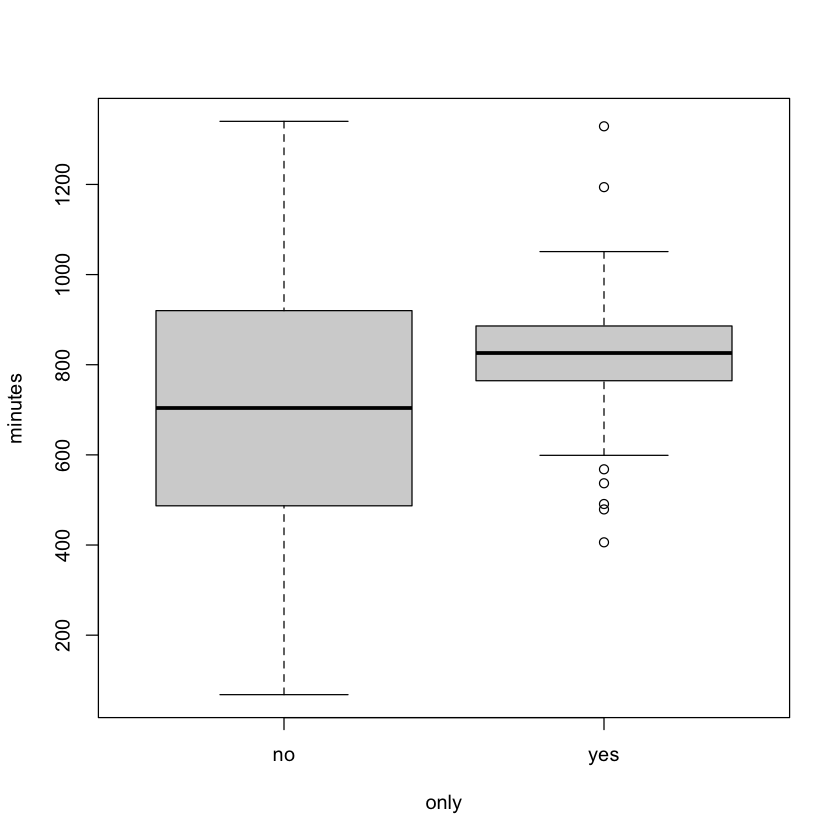

```r
boxplot(minutes~only)
```

```r
# determine if children with siblings watch more TV than those without siblings
t.test(minutes~only, alt='l', conf.level=.90)
```

```
	Welch Two Sample t-test

data:  minutes by only
t = -1.8663, df = 84.153, p-value = 0.03274
alternative hypothesis: true difference in means between group no and group yes is less than 0
90 percent confidence interval:
      -Inf -30.74327
sample estimates:
 mean in group no mean in group yes
         718.2459          818.0968
```